# R3_External_Lab

```python
import warnings
warnings.filterwarnings('ignore')
```

## K-Nearest-Neighbors

KNN falls in the supervised learning family of algorithms. Informally, this means that we are given a labelled dataset consiting of training observations (x,y) and would like to capture the relationship between x and y. More formally, our goal is to learn a function h:X→Y so that given an unseen observation x, h(x) can confidently predict the corresponding output y.

In this module we will explore the inner workings of KNN, choosing the optimal K values and using KNN from scikit-learn.

## Overview

1.Read the problem statement.

2.Get the dataset.

3.Explore the dataset.

4.Pre-processing of dataset.

5.Visualization

6.Transform the dataset for building machine learning model.

7.Split data into train, test set.

7.Build Model.

8.Apply the model.

9.Evaluate the model.

10.Finding Optimal K value

11.Repeat 7,8,9 steps.

## Problem statement

### Dataset

The data set we’ll be using is the Iris Flower Dataset which was first introduced in 1936 by the famous statistician Ronald Fisher and consists of 50 observations from each of three species of Iris (Iris setosa, Iris virginica and Iris versicolor). Four features were measured from each sample: the length and the width of the sepals and petals.

**Attributes of the dataset:** https://archive.ics.uci.edu/ml/datasets/Iris

**Train the KNN algorithm to be able to distinguish the species from one another given the measurements of the 4 features.**

```python
import pandas as pd
import numpy as np

from sklearn.model_selection import train_test_split
from sklearn.metrics import classification_report, confusion_matrix, accuracy_score
from sklearn.preprocessing import LabelEncoder
from sklearn import preprocessing
from sklearn.neighbors import KNeighborsClassifier

import matplotlib.pyplot as plt
import seaborn as sns
%matplotlib inline
```

## Question 1

Import the data set and print 10 random rows from the data set

```python
iris = pd.read_csv("iris.csv")
iris.sample(10)
```

|  | Sepal Length (in cm) | Sepal Width in (cm) | Petal length (in cm) | Petal width (in cm) | Class |
| --- | --- | --- | --- | --- | --- |
| 52 | 6.9 | 3.1 | 4.9 | 1.5 | Iris-versicolor |
| 53 | 5.5 | 2.3 | 4.0 | 1.3 | Iris-versicolor |
| 50 | 7.0 | 3.2 | 4.7 | 1.4 | Iris-versicolor |
| 27 | 5.2 | 3.5 | 1.5 | 0.2 | Iris-setosa |
| 97 | 6.2 | 2.9 | 4.3 | 1.3 | Iris-versicolor |
| 86 | 6.7 | 3.1 | 4.7 | 1.5 | Iris-versicolor |
| 37 | 4.9 | 3.1 | 1.5 | 0.1 | Iris-setosa |
| 25 | 5.0 | 3.0 | 1.6 | 0.2 | Iris-setosa |
| 147 | 6.5 | 3.0 | 5.2 | 2.0 | Iris-virginica |
| 93 | 5.0 | 2.3 | 3.3 | 1.0 | Iris-versicolor |

```python
iris.shape
```

```
(150, 5)
```

```python
iris.info()
```

```
<class 'pandas.core.frame.DataFrame'>
RangeIndex: 150 entries, 0 to 149
Data columns (total 5 columns):
Sepal Length (in cm)    150 non-null float64
Sepal Width in (cm)     150 non-null float64
Petal length (in cm)    150 non-null float64
Petal width (in cm)     150 non-null float64
Class                   150 non-null object
dtypes: float64(4), object(1)
memory usage: 5.9+ KB
```

```python
iris.describe().transpose()
```

|  | count | mean | std | min | 25% | 50% | 75% | max |
| --- | --- | --- | --- | --- | --- | --- | --- | --- |
| Sepal Length (in cm) | 150.0 | 5.843333 | 0.828066 | 4.3 | 5.1 | 5.80 | 6.4 | 7.9 |
| Sepal Width in (cm) | 150.0 | 3.054000 | 0.433594 | 2.0 | 2.8 | 3.00 | 3.3 | 4.4 |
| Petal length (in cm) | 150.0 | 3.758667 | 1.764420 | 1.0 | 1.6 | 4.35 | 5.1 | 6.9 |
| Petal width (in cm) | 150.0 | 1.198667 | 0.763161 | 0.1 | 0.3 | 1.30 | 1.8 | 2.5 |

## Question 2 - Estimating missing values

*Its not good to remove the records having missing values all the time. We may end up loosing some data points. So, we will have to see how to replace those missing values with some estimated values (median)*

```python
print ("Missing_val_count :", sum(iris.isnull().values.ravel()))
```

```
Missing_val_count : 0
```

## Question 3 - Dealing with categorical data

Change all the classes to numericals (0to2).

```python
print(iris['Class'].unique())

le = preprocessing.LabelEncoder()
iris.Class = le.fit_transform(iris.Class)
print(iris['Class'].unique())
```

```
['Iris-setosa' 'Iris-versicolor' 'Iris-virginica']
[0 1 2]
```

## Question 4

*Observe the association of each independent variable with target variable and drop variables from feature set having correlation in range -0.1 to 0.1 with target variable.*

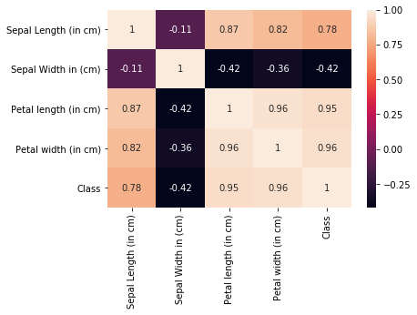

```python
sns.heatmap(iris.corr(), annot=True)
```

## Question 5

*Observe the independent variables variance and drop such variables having no variance or almost zero variance(variance < 0.1). They will be having almost no influence on the classification.*

```python
iris.var()
```

```
Sepal Length (in cm)    0.685694
Sepal Width in (cm)     0.188004
Petal length (in cm)    3.113179
Petal width (in cm)     0.582414
Class                   0.671141
dtype: float64
```

## Question 6

*Plot the scatter matrix for all the variables.*

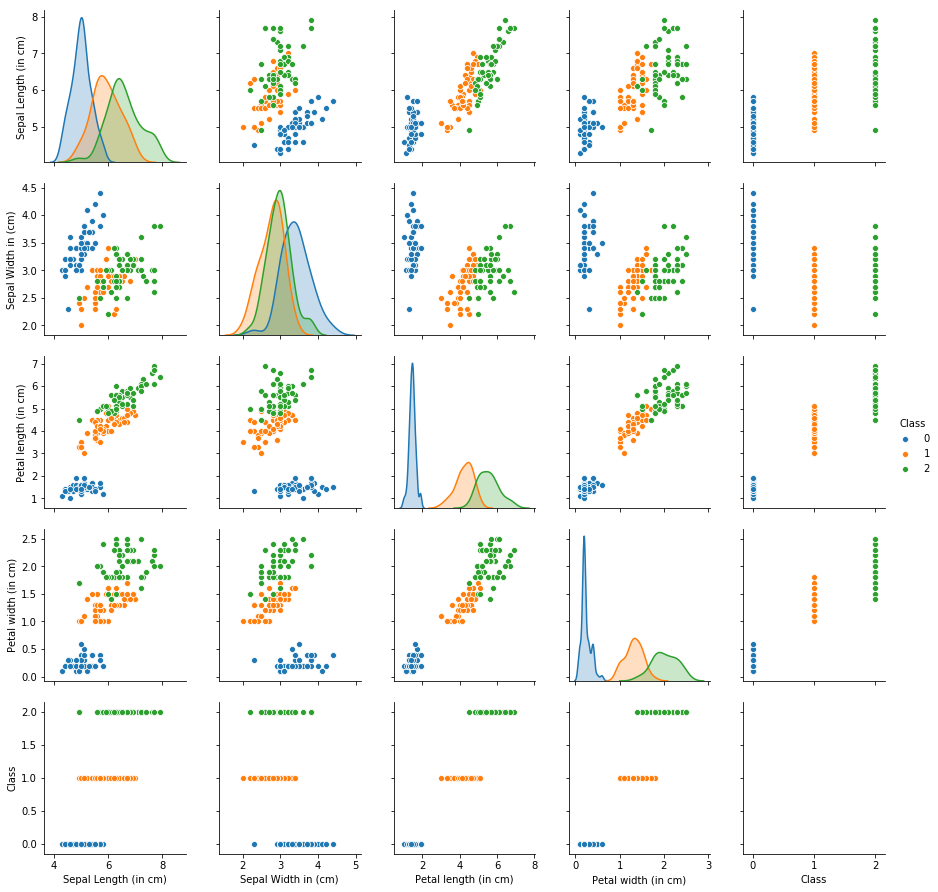

```python
sns.pairplot(iris, hue='Class')
```

## Split the dataset into training and test sets

## Question 7

*Split the dataset into training and test sets with 80-20 ratio.*

```python
Y = iris["Class"]
X = iris.drop(labels = ["Class"], axis = 1)


##X_train, X_test, Y_train, Y_test = train_test_split(X, Y, test_size=0.20, shuffle='True', random_state=42)
X_train, X_test, Y_train, Y_test = train_test_split(X, Y, test_size=0.20, random_state=42)
```

## Question 8 - Model

*Build the model and train and test on training and test sets respectively using **scikit-learn**. Print the Accuracy of the model with different values of **k=3,5,9**.*

**Hint:** For accuracy you can check **accuracy_score()** in scikit-learn

```python
for k in [3,5,9]:
    NNH = KNeighborsClassifier(n_neighbors = k, weights = 'uniform', metric = 'euclidean')
    NNH.fit(np.array(X_train), Y_train)
    Y_predict = NNH.predict(X_test)
    auc_scr = accuracy_score(Y_test,Y_predict)
    print('Accuracy rate of neighbor = %d is %0.3f'%(k,auc_scr))
```

```
Accuracy rate of neighbor = 3 is 1.000
Accuracy rate of neighbor = 5 is 1.000
Accuracy rate of neighbor = 9 is 1.000
```

## Question 9 - Cross Validation

Run the KNN with no of neighbours to be 1,3,5..19 and *Find the **optimal number of neighbours** from the above list using the Mis classification error

Hint:

Misclassification error (MSE) = 1 - Test accuracy score. Calculated MSE for each model with neighbours = 1,3,5...19 and find the model with lowest MSE

```python
k_neighbours = np.arange(1,20,2)
MSE_err = []
for k in k_neighbours:
    NNH = KNeighborsClassifier(n_neighbors = k, weights = 'uniform', metric = 'euclidean')
    NNH.fit(np.array(X_train),Y_train)
    Y_predict = NNH.predict(X_test)
    MSE = 1 - accuracy_score(Y_test,Y_predict)
    MSE_err.append(MSE)
    print('Misclassification Error for %d neighbors is %0.3f'%(k,MSE))
```

```
Misclassification Error for 1 neighbors is 0.000
Misclassification Error for 3 neighbors is 0.000
Misclassification Error for 5 neighbors is 0.000
Misclassification Error for 7 neighbors is 0.033
Misclassification Error for 9 neighbors is 0.000
Misclassification Error for 11 neighbors is 0.000
Misclassification Error for 13 neighbors is 0.000
Misclassification Error for 15 neighbors is 0.000
Misclassification Error for 17 neighbors is 0.000
Misclassification Error for 19 neighbors is 0.000
```

## Question 10

*Plot misclassification error vs k (with k value on X-axis) using matplotlib.*

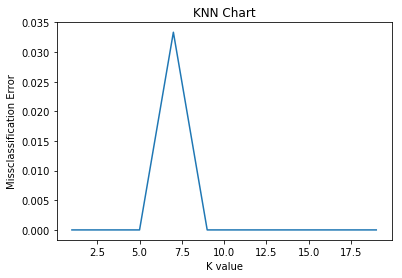

```python
plt.title('KNN Chart')
plt.xlabel('K value')
plt.ylabel('Missclassification Error')
plt.plot(k_neighbours, MSE_err)
plt.show()
```